# Analysing your data

If you want to cite this script please refer to the idtracker.ai paper: Romero-Ferrero, Bergomi, Hinz, Heras & Polavieja, bioRxiv, 2018 (submitted to a journal, under review)

The methods in this script are also available as part of a Matlab toolkit, idSocial (http://www.idtracker.es/idsocial, see Ontogeny of collective behavior, Hinz, de Polavieja, PNAS, Feb 2017). They are being implemented in Python in the package trajectorytools (github.com/fjhheras/trajectorytools).

Some jupyter notebook help:  
Enter edit mode: Select cell & Enter  
Run cell + Select below: Shift-Enter  
Run cell: Ctrl-Enter  
Enter command mode: Ctrl-M  
Insert cell above/below: A/B

```python
import os
import numpy as np
import matplotlib.pyplot as plt
from matplotlib.pyplot import figure
from trajectorytools.constants import dir_of_data
import trajectorytools as tt
import trajectorytools.plot as ttplot
import trajectorytools.socialcontext as ttsocial
from scipy import stats
```

## Loading and preparing the trajectories

```python
framerate = 30;
dir_of_data = os.path.expanduser('/home/polaviejalab/trajectories-git/10/first/1/')
trajectories_file = os.path.join(dir_of_data, 'trajectories_wo_gaps.npy')
tr = tt.Trajectories.from_idtracker(trajectories_file,smooth_sigma=0.5)
no_fish = tr.number_of_individuals
no_frames = tr.number_of_frames
print("Number of fish: ", no_fish)
```

```
WARNING:root:Miniball was not used for centre detection
WARNING:root:Please, install https://github.com/weddige/miniball
```

```
Number of fish:  10
```

## Plot trajectories

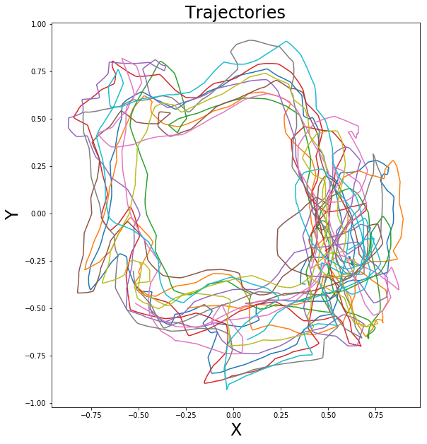

```python
fig, ax_trajectories = plt.subplots(figsize=(10,10))
frame_range = range(framerate*60) # Select only the first 60 seconds for plotting

for i in range(no_fish):
    ax_trajectories.plot(tr.s[frame_range,i,0], tr.s[frame_range,i,1])

    ax_trajectories.set_aspect('equal','box')
    ax_trajectories.set_title('Trajectories',fontsize=24)
    ax_trajectories.set_xlabel('X',fontsize=24)
    ax_trajectories.set_ylabel('Y',fontsize=24)
```

#### Exercise: Plot trajectories for a single individual.

## Speed and Acceleration

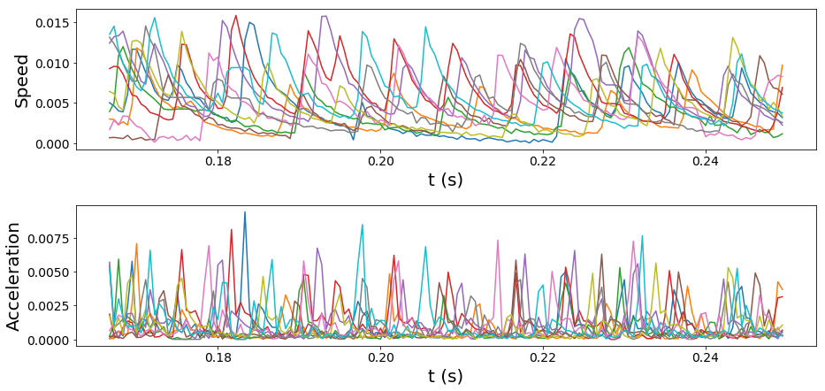

```python
fig, ax = plt.subplots(2,figsize=(15,7))
frame_range = range(10*framerate, 15*framerate,1) # Select only the first 60 seconds for plotting

for focal in range(no_fish):
    ax[0].plot(np.asarray(frame_range)/framerate/60,tr.speed[frame_range,focal])
    ax[1].plot(np.asarray(frame_range)/framerate/60,tr.acceleration[frame_range,focal])
    plt.subplots_adjust(hspace = .4)

ax[0].set_xlabel('t (s)',fontsize=20)
ax[0].set_ylabel('Speed',fontsize=20)
ax[0].tick_params(labelsize=14)

ax[1].set_xlabel('t (s)',fontsize=20)
ax[1].set_ylabel('Acceleration',fontsize=20)
ax[1].tick_params(labelsize=14)
```

#### Exercise: Plot the x- and y-coordinates versus time

### Plot histograms for each fish

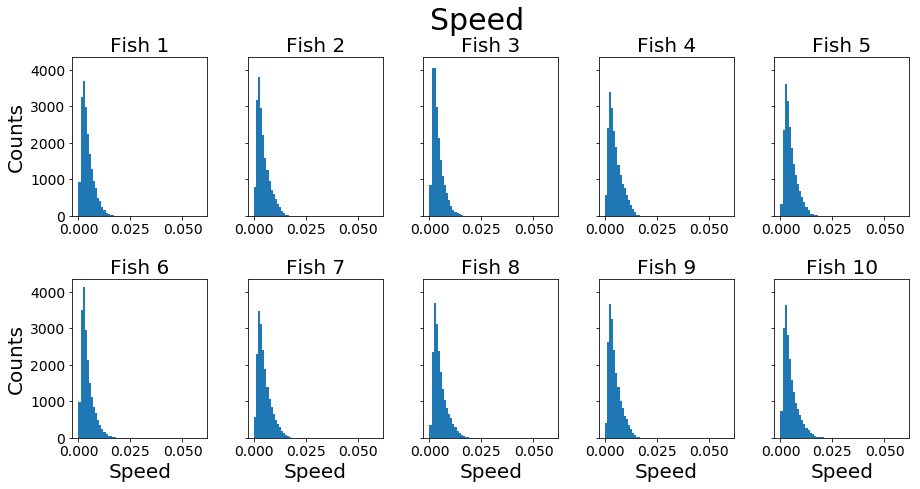

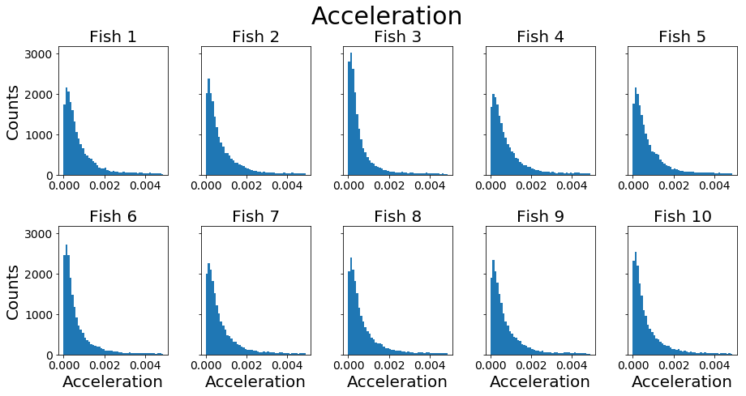

```python
def histogram(data, nbins, label):
    figv, ax_hist = plt.subplots(2,5,figsize=(15,7), sharey=True)
    ax_flat = [ax for axrow in ax_hist for ax in axrow]
    for ax, focal in zip(ax_flat, range(no_fish)):
        ax.hist(data[:, focal],nbins)
        ax.tick_params(labelsize=14)
        ax.set_title("Fish {}".format(focal+1),fontsize=20)
        if ax.is_last_row():
            ax.set_xlabel(label,fontsize = 20)
        if ax.is_first_col():
            ax.set_ylabel('Counts',fontsize = 20)
    return figv, ax_flat

# Plot speed histograms for each fish
nbins = np.arange(0,0.06,.001)
figv, ax_flat = histogram(tr.speed, nbins, "Speed")
figv.subplots_adjust(wspace = .3,hspace = .4)
figv.suptitle('Speed', fontsize = 30);

# Plot acceleration histograms for each fish
nbins = np.arange(0,0.005,.0001)
figva, ax_flata = histogram(tr.acceleration, nbins, "Acceleration")
figva.subplots_adjust(wspace = .3,hspace = .4)
figva.suptitle('Acceleration', fontsize = 30);
```

## Relative neighbour positions

In a coordinate system in which the focal individual is at the center and moving in direction of the positive y-axis, we can analyse the probability of finding neighbors at certain relative positions, and how the focal individual reacts in terms of left/right turns and increase/decrease in speed.

```python
# Rotate neighbor positions and acceleration vectors to the focal system:

s_rotated = np.empty((no_frames, no_fish, no_fish, 2))
a_rotated = tt.fixed_to_comoving(tr.a,tr.e)

for focal in range(no_fish):
    s = tt.center_in_individual(tr.s,focal)
    sr = tt.fixed_to_comoving(s,tr.e[:,focal,:])
    sr[:,focal] = np.nan # Change rotated positions of the focal itself from '0' to 'NaN'.
    s_rotated[:,focal,:,:] = sr


    a_rotated[:,focal,:] = tt.fixed_to_comoving(tr.a[:,focal],tr.e[:,focal]) # Rotate the focal's
    # acceleration vector. The x-component of the rotated vector contains the acceleration perpendicular to the
    # focal's direction of movement ('turning'), the parallel component contains the increase/decrease of speed.


# Pool together relative neighbor positions and focal acceleration vectors
sr_flat = s_rotated.reshape((-1,1,2))
ar_flat = np.repeat(a_rotated[:,:,np.newaxis,:],no_fish,2).reshape((-1,1,2))
```

### 2D-Histogram, all focal-neighbour pairs pooled together

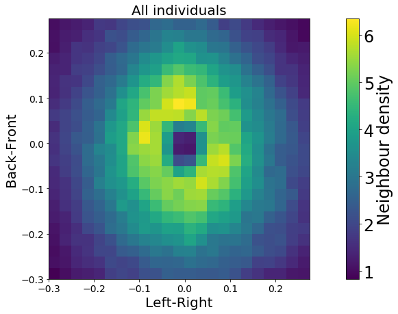

```python
# Define bin edges: (left/bottom limit, right/top limit, bin width)
bins = [np.arange(-.3,.3,.025),np.arange(-.3,.3,.025)]

x = sr_flat[:,0,0]
y = sr_flat[:,0,1]

# Clean data from 'Nans'
y = y[~np.isnan(x)]
x = x[~np.isnan(x)]

# Plot the histogram
H, xedges, yedges = np.histogram2d(y,x,bins = bins,normed = True) # x and y are switched to comply with np.histogram2d convention
X, Y = np.meshgrid(xedges, yedges)
fig, ax_meanposmap = plt.subplots(figsize=(19,7))
im = ax_meanposmap.pcolormesh(X, Y, H)

# Add colorbar, labels, etc.
ax_cb = fig.colorbar(im, ax=ax_meanposmap)
ax_meanposmap.set_aspect('equal','box')
ax_meanposmap.set_title('All individuals',fontsize=20);
ax_meanposmap.set_xlabel('Left-Right',fontsize = 20)
ax_meanposmap.set_ylabel('Back-Front',fontsize = 20)
ax_meanposmap.tick_params(labelsize=14)
ax_cb.ax.tick_params(labelsize=24)
ax_cb.set_label('Neighbour density',fontsize=24)
```

#### Exercise: Change the resolution/binsize of the histogram.

## Polar 2D-histograms and maps of turning and acceleration maps depending on neighbor positions

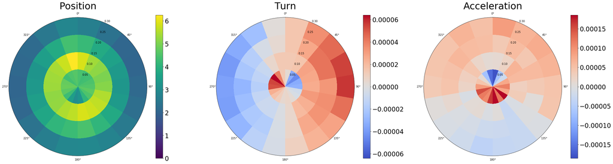

```python
# interpolate_polarmap_angles has merely a cosmetic purpose:
# It smoothes the corners in plot_polar_histogram/pcolormesh
def interpolate_polarmap_angles(histogram, theta_edges, r_edges, factor = 1):
    histogram_interpolated = np.zeros((histogram.shape[0], histogram.shape[1]*factor))
    for k in range(factor):
        histogram_interpolated[:,k::factor] = histogram
    theta_edges = np.linspace(-np.pi, np.pi, (theta_edges.shape[0]-1)*factor + 1)
    Theta, R = np.meshgrid(theta_edges, r_edges)
    return histogram_interpolated, Theta, R

num_bins_r = 4     # Number of bin edges in radial direction
num_bins_theta = 18 # Number of bin edges in angular direction

# Create polar edges
r_edges = np.linspace(0, .3, num_bins_r + 1)
theta_edges = np.linspace(-np.pi, np.pi, num_bins_theta + 1)

# Transform cartesian to polar coordinates
r = np.sqrt(sr_flat[:,0,0]**2 + sr_flat[:,0,1]**2)
theta = np.arctan2(sr_flat[:,0,0], sr_flat[:,0,1])

# Select the array for binned statistics/mapping
map_value = ar_flat[:,0,:]

# Calculate the 2d histogram and binned statistics for focal turning and acceleration
Pos = stats.binned_statistic_2d(r, theta, None, 'count', bins=np.asarray([r_edges,theta_edges]))
Turn = stats.binned_statistic_2d(r, theta, map_value[:,0], np.nanmean, bins=np.asarray([r_edges,theta_edges]))
Fwd = stats.binned_statistic_2d(r, theta, map_value[:,1], np.nanmean, bins=np.asarray([r_edges,theta_edges]))

# Calculate binsize for normalization (binsize increases with radius)
dr = np.pi*(r_edges[1:]**2 - r_edges[0:-1]**2)
dtheta = (theta_edges[1] - theta_edges[0])/(2*np.pi)
area = np.repeat(dtheta*dr[:,np.newaxis],theta_edges.shape[0]-1,1)

# plot_polar_histogram plots the polar histograms and maps
def plot_polar_histogram(values, label, ax, cmap=None, sym=False):

    Theta, R = np.meshgrid(theta_edges, r_edges)
    mp, Theta, R = interpolate_polarmap_angles(values, theta_edges, r_edges, factor = 5)

    # Select color limits:
    if sym:
        vmax = np.max(np.abs(values))
        vmin = -vmax
    else:
        vmax = np.max(values)
        vmin = 0

    # Plot histogram/map
    im = ax.pcolormesh(Theta, R, mp, cmap=cmap, vmin=vmin, vmax=vmax)
    cb = fig.colorbar(im, ax=ax, cmap=cmap)
    cb.ax.tick_params(labelsize=24)
    ax.set_title(label,fontsize=36)

    # Adjusting axis and sense of rotation to make it compatible with [2]:
    # Direction of movement along vertical axis, angles increase in clockwise
    ax.set_theta_zero_location("N")
    ax.set_theta_direction(-1)

figure(num=None, figsize=(40, 10), facecolor='w', edgecolor='k')
# Plot polar histogram/maps for relative neighbor positions, turning and acceleration
plot_polar_histogram(Pos.statistic/area/np.sum(Pos.statistic), 'Position', plt.subplot(131, polar=True))
plot_polar_histogram(Turn.statistic, 'Turn', plt.subplot(132, polar=True), cmap=plt.get_cmap('coolwarm'),sym=True)
plot_polar_histogram(Fwd.statistic, 'Acceleration', plt.subplot(133, polar=True), cmap=plt.get_cmap('coolwarm'), sym = True)
```

#### Exercise: Plot Position, Turning and Acceleration for a single individual.

## Inter-Individual Distances

### Calculate interindividual distances

```python
def interindividual_distance(trajectories):
    amatrix = ttsocial.adjacency_matrix(trajectories, mode='distance')
    for i in range(amatrix.shape[1]):
        amatrix[:,i,i] = np.nan
    return amatrix

distances = interindividual_distance(tr.s).reshape((-1,no_fish))
```

### Generate shuffled trajectories and control distances

```python
def shuffle_trajectories(trajectories, focal=None):
    num_fish = trajectories.shape[1]
    neighbor_idces = [i for i in range(num_fish) if i != focal]
    #print(neighbor_idces)
    t_shuffle = trajectories.copy()
    t_shuffle[:,neighbor_idces] = np.random.permutation(t_shuffle[:,neighbor_idces])
    return t_shuffle

def distance_to_focal(trajectories, focal=None):
    num_fish = trajectories.shape[1]
    distances = np.sqrt(np.sum((trajectories[:,[focal]] - np.delete(trajectories, focal, axis=1) )**2, axis=2))
    return distances #np.delete(distances, focal, axis=1)

# Calculate control data: For each focal individual, shuffle the neighbor positions, then
# calculate the distance between the original focal positions and the randomized neighbor positions.
distances_shuffled = np.empty((no_frames*(no_fish-1),no_fish))
for focal in range(no_fish):
    t_shuffle = shuffle_trajectories(tr.s, focal)
    d_ = distance_to_focal(t_shuffle, focal)
    distances_shuffled[:,focal] = d_[:,:].reshape(-1) # Pool all neighbor distances for 'focal'
```

### Plot distance histograms

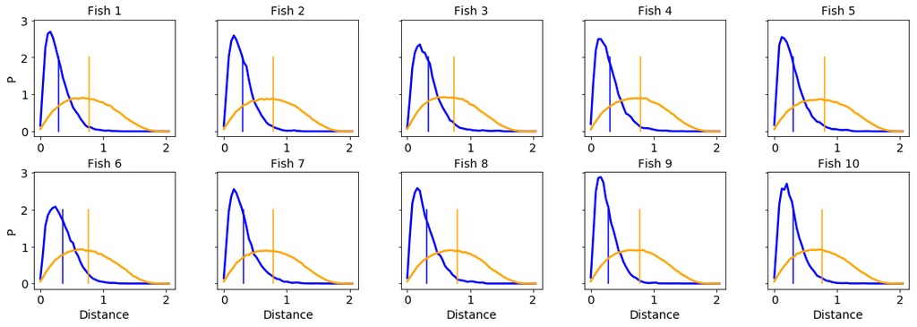

```python
# Mean inter-individual distance to all neighbor animals for each focal.

def plot_histogram_and_mean(data, ax, color='r'):
    nbins = np.arange(0,2.1,0.04)
    d_mean = np.mean(data)
    hist = np.histogram(data,nbins,density = True)
    line = ax.plot(nbins[:-1],hist[0], linewidth=2.5, color=color)
    ax.plot((d_mean, d_mean), (0, 2), color = color)

fig, ax_hist = plt.subplots(2,5,figsize=(19,6), sharey=True)
ax_flat = [ax for axrow in ax_hist for ax in axrow]

for ax, focal in zip(ax_flat, range(no_fish)):

    # Get rid of "NaNs":
    data = distances[:,focal]
    data = data[~np.isnan(data)]

    plot_histogram_and_mean(data, ax, color = 'b')
    plot_histogram_and_mean(distances_shuffled[:,focal], ax, color = 'orange')

    # Some design parameters
    ax.tick_params(labelsize=14)
    ax.set_title("Fish {}".format(focal+1),fontsize=14)

    if ax.is_last_row():
        ax.set_xlabel('Distance', fontsize=14)
    if ax.is_first_col():
        ax.set_ylabel('P',fontsize=14)

plt.subplots_adjust(wspace = .3,hspace = .3)
```